# Gviz for PDE4DIP

C.J. Liu

1/17/2017

# 1 Gviz for PDE4DIP

## 1.1 Level-1 Ideogram

Set genome as hg38 Chomosome as chromosome 1

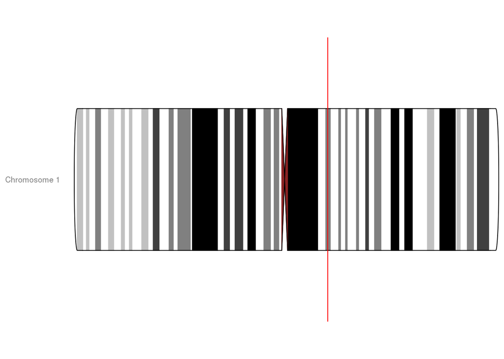

## 1.2 Level-2 Coordinates

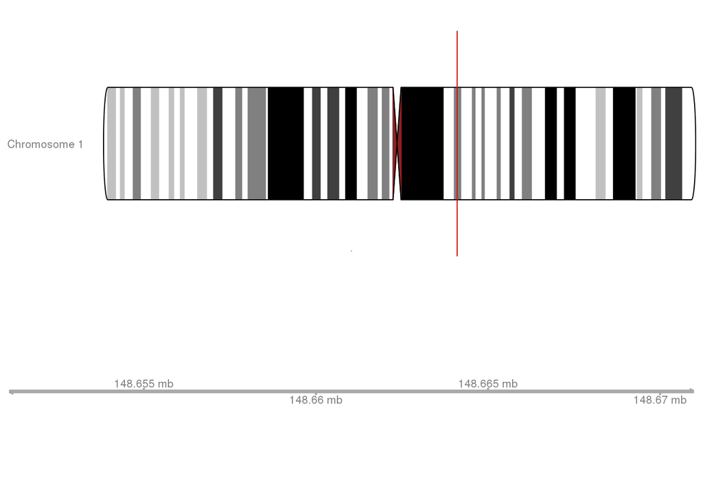

## 1.3 Level-4 Gene Model of PDE4DIP

The point mutation in the NBPF14 intron. also plot NBPF14 gene model.

### 1.3.1 Get NBPF14 and PDE4DIP gene medels

PDEDIP ensembl ID is **ENSG00000178104**  
NBPF14 ensembl ID is **ENSG00000270629**

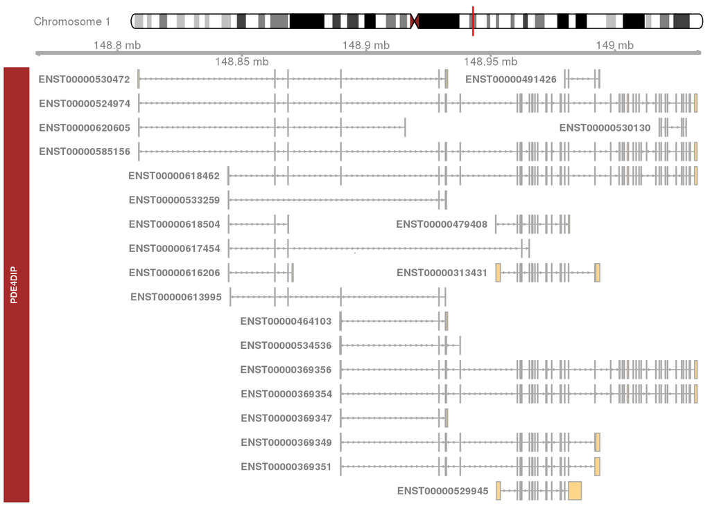

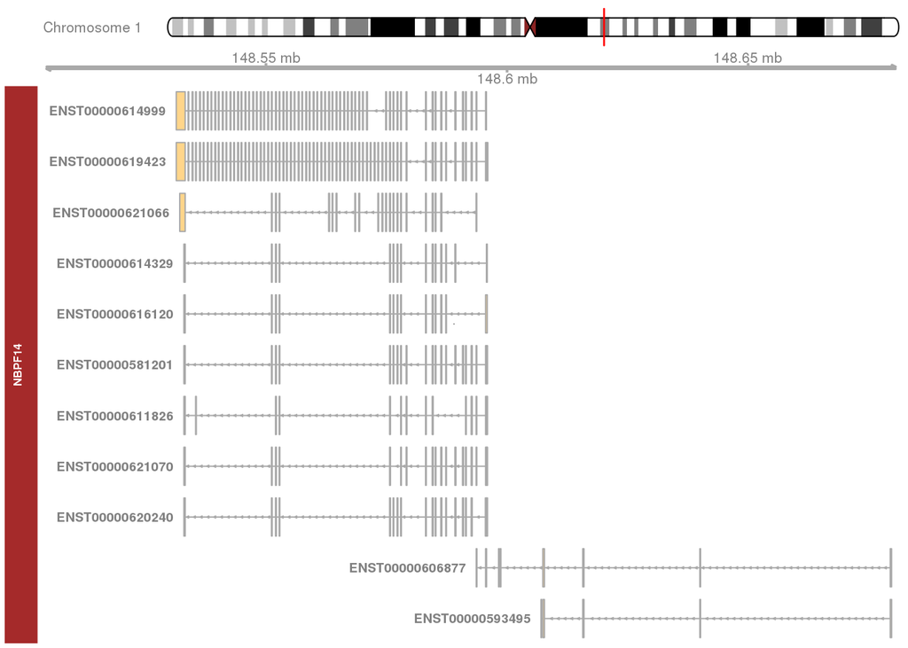

### 1.3.2 Plot PDE4DIP and NBPF14 transcripts

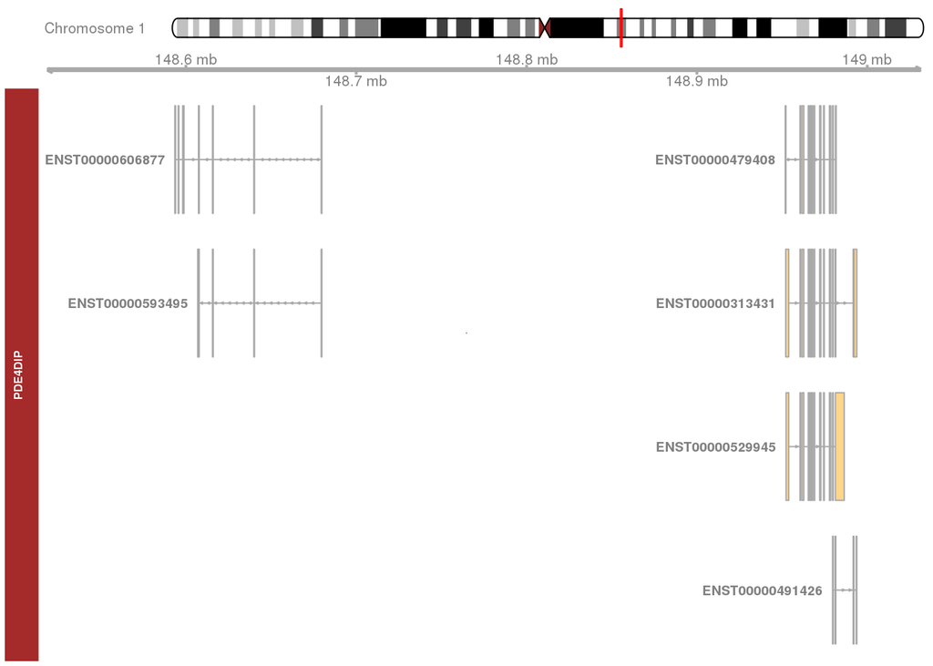

## 1.4 Level-3 TF binding/regulation position

1. Extract all transcripts of PDE4DIP
2. Find TF of 1000 up stream transcripts.
3. Mutation of ENSR bind motif for USF1, and TCF7L2

### 1.4.1 Get PDE4DIP all transcripts and 1000 upstream positions.

### 1.4.2 ENSR00000013230 binding TFs

chr1 148660601 148664799 ENSR00000013230

chr1 148660601 148660614 USF1 chr1 148661025 148661133 TCF7L2

chr1:148661025-148661133 TCF7L2[108] TGACTT[**A>T**]TCTTTTGCTATGGGTACACTGTCTTTTCATGTGGCCTCAAAGAAATAGTTGAGCCATTATTGTTGTTGATAATGACGAGCAGATGCTGATGGGATGATTGC

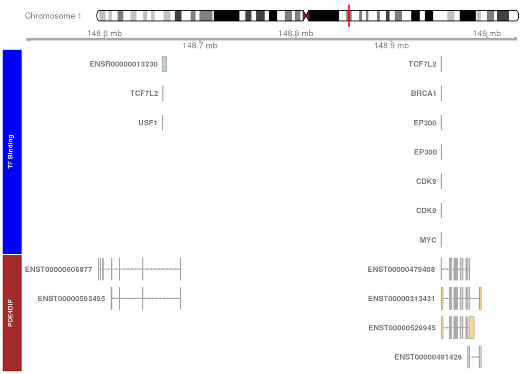

## 1.5 Level-5 Load expression data

Expression data was generated by scripts `nearestGeneExpression2`.

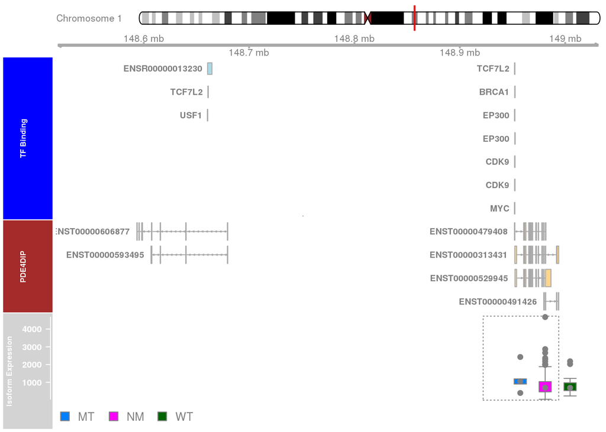

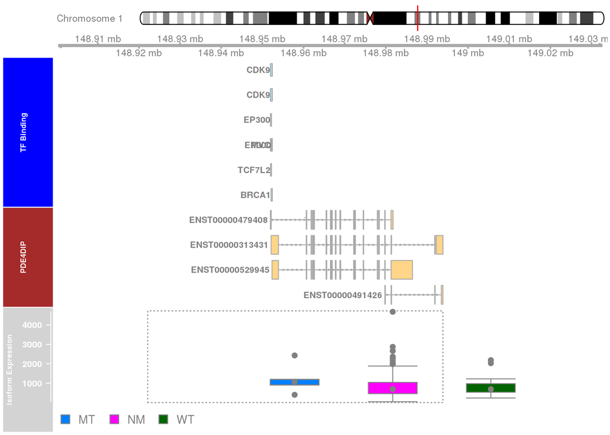

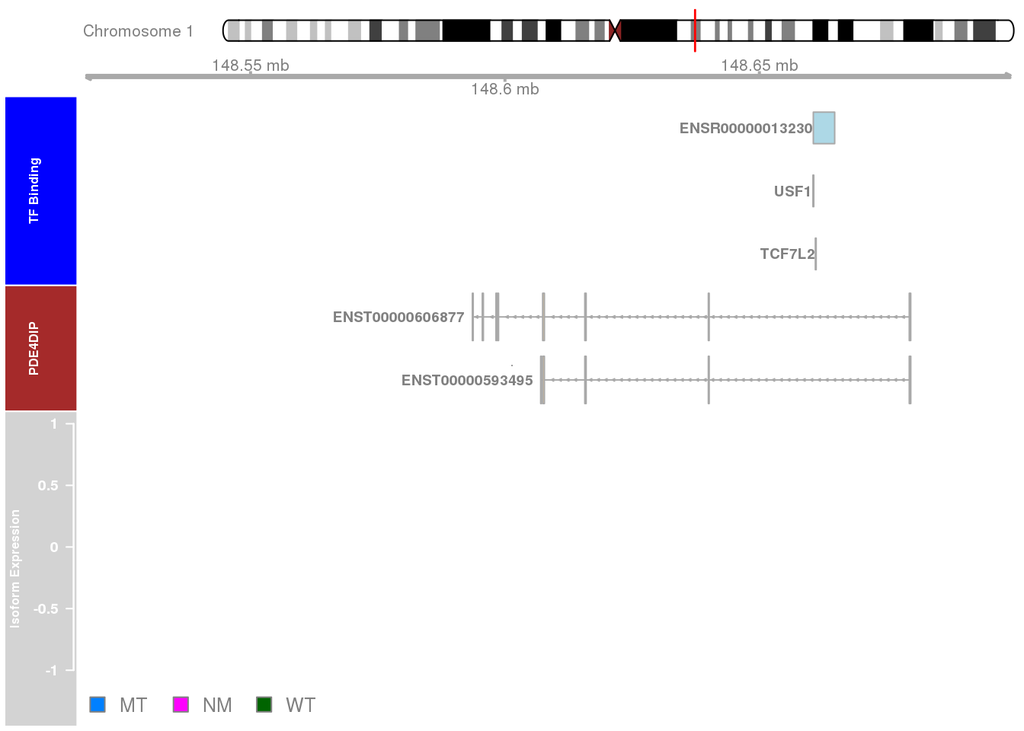

## 1.6 Level-6 Hightlight mutation

The point mutation **chr1:148661032A>T**

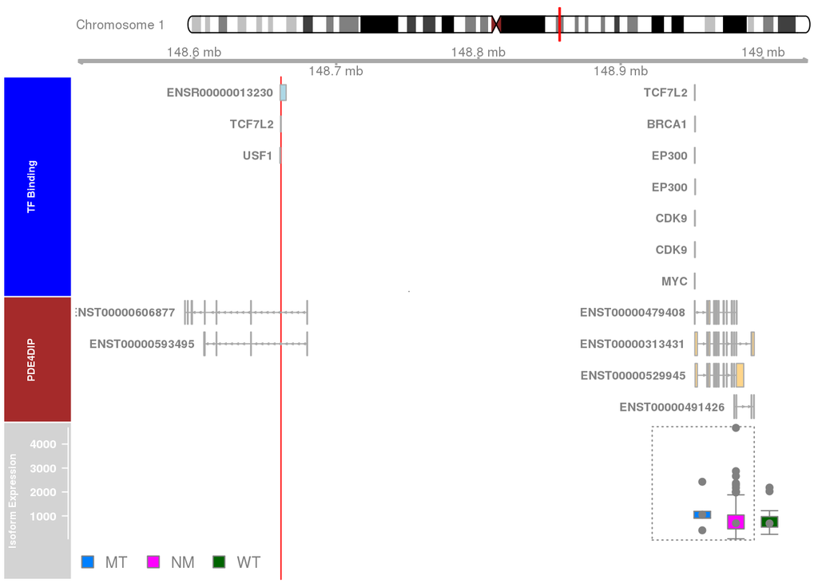

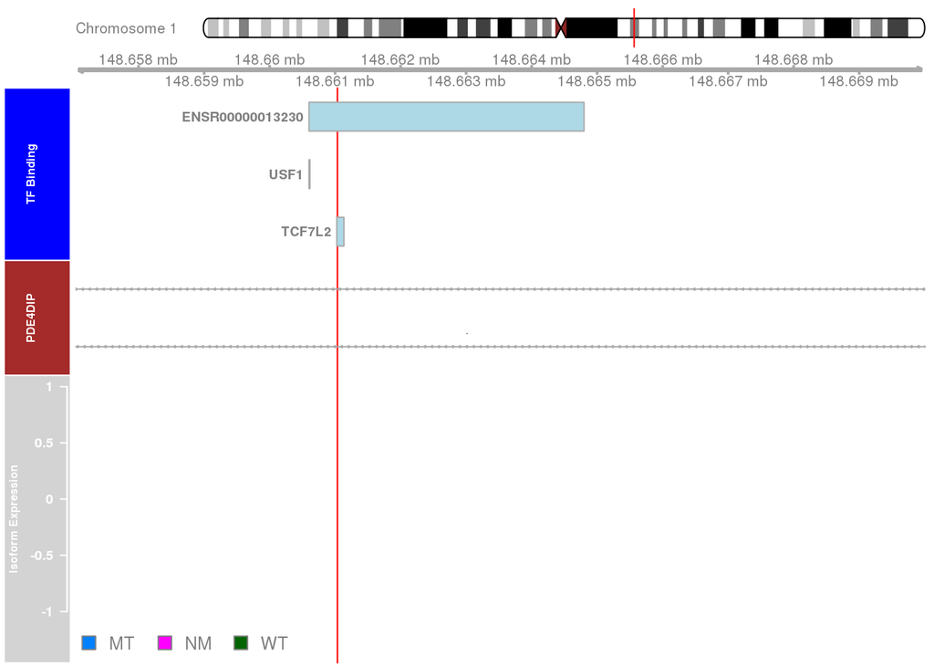

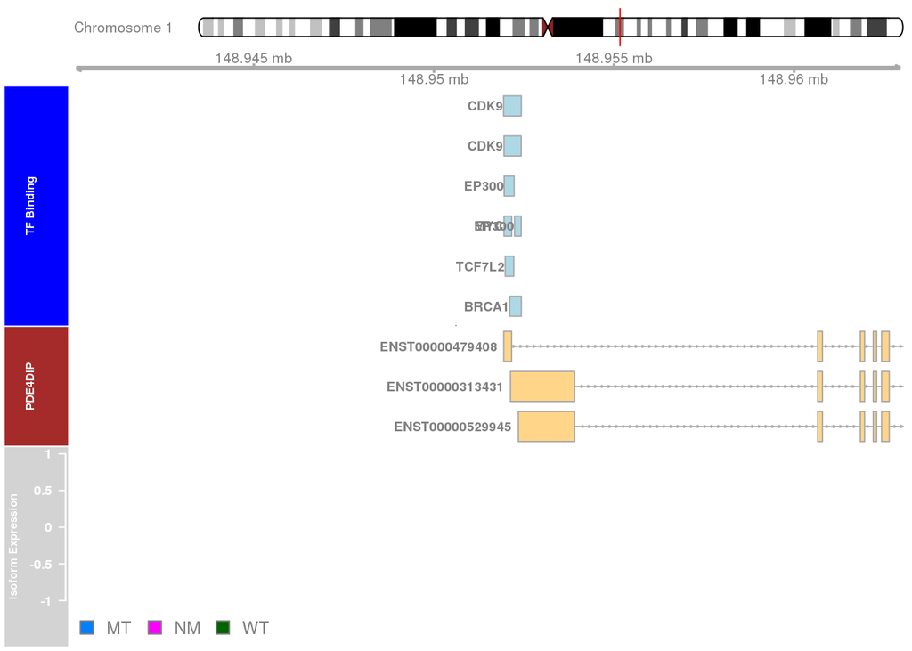